# Automated Detection of Human Activity

Simeon Evlakhov

28 july 2017 г

# Coursera Course Project

## Abstract

In this report we develop a model for automated detection of human activity.

## Introduction

Nowadays, wearable devices such as *Jawbone Up*, *Nike FuelBand*, and *Fitbit* became widespread and relatively cheap, so it is possible to collect a large amount of data about personal activity. These data can be use in various fields, particularly in improvement of fitness trainings. Different activities correspond to the different patterns of data, so it’s possible to detect the type of the activity by looking at the data.

More information is available here: http://groupware.les.inf.puc-rio.br/har (see the section on the Weight Lifting Exercise Dataset).

## Data Files

The main data file can be obtained from the following URL:

```r
train_file_url = "https://d396qusza40orc.cloudfront.net/predmachlearn/pml-training.csv"
```

If we still have no local copy of the data, now it’s time to download them to our PC:

```r
train_file_name = "pml-training.csv"
if (!file.exists(train_file_name)){
  download.file(train_file_url, train_file_name)
}
```

## Data Description

Let’s load our dataset into R environment. As many columns contains invalid data, we set **as.is** parameter equal to **TRUE**, so they will be considered as “characters” rather than “factors”.

```r
   pml_training <- read.table("pml-training.csv", header=TRUE, sep=",", as.is = TRUE)
```

The table is rather big:

```r
  dim(pml_training)
```

```
## [1] 19622   160
```

We won’t give here complete description of the columns, if you want you can refer to the original paper of Velloso et al.: [Qualitative Activity Recognition of Weight Lifting Exercises](http://groupware.les.inf.puc-rio.br/public/papers/2013.Velloso.QAR-WLE.pdf) or see the Appendix.

The most important column for us is the last one, **classe**, that contains information about activiy. Each letter in this column corresponds to a cirtain type of the activity: excercises completed exactly according to the specification (Class A), throwing the elbows to the front (Class B), lifting the dumbbellonly halfway (Class C), lowering the dumbbell only halfway (Class D) and throwing the hips to the front (Class E).

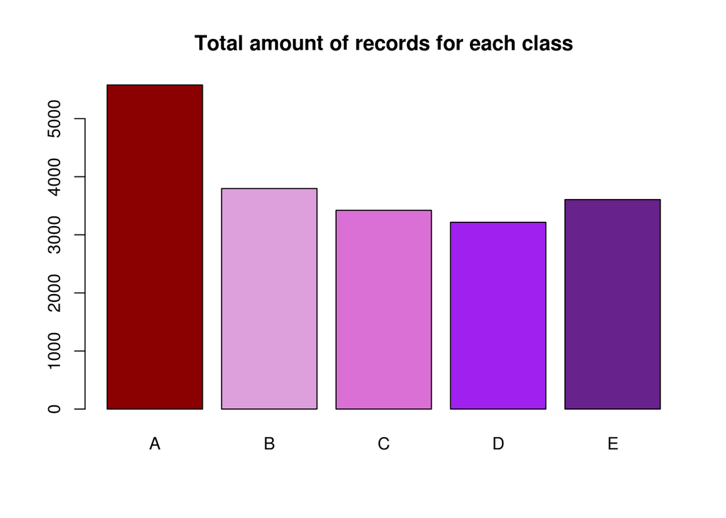

```r
  classesTbl <- table(pml_training$classe)
  {barplot(classesTbl, col=c("red4", "plum", "orchid","purple", "darkorchid4"))
  title(main="Total amount of records for each class")}
```

## Data Preprocessing

First of all, we will load libraries, that we will use later

```r
   library(plyr)
   library(dplyr)
   library(knitr)
   library(caret)
```

```r
  names(pml_training)[1:8]
```

```
## [1] "X"                    "user_name"            "raw_timestamp_part_1"
## [4] "raw_timestamp_part_2" "cvtd_timestamp"       "new_window"
## [7] "num_window"           "roll_belt"
```

It was stated on the PML Course Forum, that these data allows us to predict the result with 100% accuracy (for the cross-validation set), but in real life we can hardly get all this information, so it’s better to ignore it completely (we will do it in a second).

Columns from 8 to 159 contains numeric info with tons of incorrect data, so some of them were interpreted as “characters”. Now we will fix this problem:

```r
for (i in 8:159){
  if (class(pml_training[,i])=="character"){
    pml_training[,i] <- as.numeric(pml_training[,i])
  }
}
```

It is time to remove unnecessary columns, i.e. first 7 columns and columns that contains different types of summaries: mean, variance, standard deviation, max, min, amplitude and kurtosis. These columns contain a lot of “NAs” and it is rather hard to use them in real life.

```r
summary_columns <- grep("(max)|(min)|(kurtosis)|(skewness)|(amplitude)|(var)|(avg)|(stddev)",
                        names(pml_training))
```

```r
 filtered_pml_training <- pml_training[, -(c(1:7, summary_columns))]
```

Finally, we should divide our set into training and cross validation subsets. We will use the last one to choose the appropriate model:

```r
  set.seed(2583)
  inTrain <- createDataPartition(y=filtered_pml_training$classe, p=0.8, list=FALSE)
  training <- filtered_pml_training[inTrain,]
  cross_validation <- filtered_pml_training[-inTrain,]
```

## Models

It’s possible to use different models for prediction: SVM, Boosting, Random Forests etc. It is mentioned in the paper of Velloso et all that all of them give considerably good results. In this paper we will compare only two methods: Gradient Boosting Machine and Random Forests.

## Training

First, we split our data frame into feature columns and target column:

```r
  x <- training[,-53]
  y <- training[, 53]
```

### Parallelizing

The main technical problem with training is that it takes a lot of time. To make it run faster, it is a good idea to use parallel computations. The following three code chunks was proposed by Leonard Greski, Course Mentor on https://www.coursera.org/learn/practical-machine-learning/discussions/weeks/4/threads/ijErxyavEee6ugr9raNa5As

We have to include libraries:

```r
  library(parallel)
  library(doParallel)
```

create clusters:

```r
  cluster <- makeCluster(detectCores() - 1)
  registerDoParallel(cluster)
```

and tune training parameters:

```r
  fitControl <- trainControl(method="cv", number=10, allowParallel = TRUE)
```

Now we can run our training procedure (takes about an hour for each model on my laptop, Intel Pentium N3710:

```r
  modFitRf <- train(x,y,  method="rf", data=training, trControl=fitControl)
```

```r
  modFitGbm <-train(x, y,  method="gbm", verbose=FALSE, trControl = fitControl)
```

The following code is due to Leonard Greski. It simply stops our parallel infrastructure.

```r
  stopCluster(cluster)
  registerDoSEQ()
```

## Testing

Now let’s compare the results of the to methods. To do this, we should run our models on cross validation sets:

```r
  predRf <- predict(modFitRf, cross_validation)
  predGbm <- predict(modFitGbm, cross_validation)
```

Here is some info about the models:

```r
  kable(modFitRf$results)
```

| mtry | Accuracy | Kappa | AccuracySD | KappaSD |
| --- | --- | --- | --- | --- |
| 2 | 0.9928653 | 0.9909742 | 0.0022654 | 0.0028665 |
| 27 | 0.9928655 | 0.9909746 | 0.0015267 | 0.0019313 |
| 52 | 0.9860497 | 0.9823518 | 0.0023557 | 0.0029780 |

```r
  kable(modFitGbm$results)
```

|  | shrinkage | interaction.depth | n.minobsinnode | n.trees | Accuracy | Kappa | AccuracySD | KappaSD |
| --- | --- | --- | --- | --- | --- | --- | --- | --- |
| 1 | 0.1 | 1 | 10 | 50 | 0.7538703 | 0.6879698 | 0.0105912 | 0.0132233 |
| 4 | 0.1 | 2 | 10 | 50 | 0.8554045 | 0.8167348 | 0.0094439 | 0.0119792 |
| 7 | 0.1 | 3 | 10 | 50 | 0.8980190 | 0.8708795 | 0.0070236 | 0.0089371 |
| 2 | 0.1 | 1 | 10 | 100 | 0.8211977 | 0.7736607 | 0.0110919 | 0.0140439 |
| 5 | 0.1 | 2 | 10 | 100 | 0.9090377 | 0.8848466 | 0.0068463 | 0.0086863 |
| 8 | 0.1 | 3 | 10 | 100 | 0.9422252 | 0.9268838 | 0.0044282 | 0.0056056 |
| 3 | 0.1 | 1 | 10 | 150 | 0.8552141 | 0.8167359 | 0.0065963 | 0.0083700 |
| 6 | 0.1 | 2 | 10 | 150 | 0.9318422 | 0.9137409 | 0.0059210 | 0.0074966 |
| 9 | 0.1 | 3 | 10 | 150 | 0.9617181 | 0.9515662 | 0.0036256 | 0.0045833 |

We can see, that the first model (Random Forests) is by far more accurate than Gbm, at least on the training set. To see the results on the cross validation set, let’s build confusion matrices:

```r
  confMxRf <- confusionMatrix(predRf, cross_validation$classe)
  confMxGbm <- confusionMatrix(predGbm, cross_validation$classe)
```

Some overall info:

```r
  confMxRf$overall
```

```
##       Accuracy          Kappa  AccuracyLower  AccuracyUpper   AccuracyNull
##      0.9979607      0.9974205      0.9959858      0.9991192      0.2844762
## AccuracyPValue  McnemarPValue
##      0.0000000            NaN
```

```r
  confMxGbm$overall
```

```
##       Accuracy          Kappa  AccuracyLower  AccuracyUpper   AccuracyNull
##      0.9640581      0.9545188      0.9577496      0.9696625      0.2844762
## AccuracyPValue  McnemarPValue
##      0.0000000            NaN
```

And performance tables:

```r
  kable(confMxRf$byClass, digits=3)
```

|  | Sensitivity | Specificity | Pos Pred Value | Neg Pred Value | Precision | Recall | F1 | Prevalence | Detection Rate | Detection Prevalence | Balanced Accuracy |
| --- | --- | --- | --- | --- | --- | --- | --- | --- | --- | --- | --- |
| Class: A | 1.000 | 1.000 | 0.999 | 1.000 | 0.999 | 1.000 | 1.000 | 0.284 | 0.284 | 0.285 | 1.000 |
| Class: B | 0.999 | 1.000 | 0.999 | 1.000 | 0.999 | 0.999 | 0.999 | 0.193 | 0.193 | 0.193 | 0.999 |
| Class: C | 0.996 | 0.999 | 0.996 | 0.999 | 0.996 | 0.996 | 0.996 | 0.174 | 0.174 | 0.174 | 0.997 |
| Class: D | 0.995 | 0.999 | 0.995 | 0.999 | 0.995 | 0.995 | 0.995 | 0.164 | 0.163 | 0.164 | 0.997 |
| Class: E | 0.999 | 1.000 | 1.000 | 1.000 | 1.000 | 0.999 | 0.999 | 0.184 | 0.184 | 0.184 | 0.999 |

```r
  kable(confMxGbm$byClass, digits=3)
```

|  | Sensitivity | Specificity | Pos Pred Value | Neg Pred Value | Precision | Recall | F1 | Prevalence | Detection Rate | Detection Prevalence | Balanced Accuracy |
| --- | --- | --- | --- | --- | --- | --- | --- | --- | --- | --- | --- |
| Class: A | 0.986 | 0.990 | 0.974 | 0.994 | 0.974 | 0.986 | 0.980 | 0.284 | 0.280 | 0.288 | 0.988 |
| Class: B | 0.938 | 0.986 | 0.941 | 0.985 | 0.941 | 0.938 | 0.939 | 0.193 | 0.181 | 0.193 | 0.962 |
| Class: C | 0.955 | 0.986 | 0.936 | 0.990 | 0.936 | 0.955 | 0.945 | 0.174 | 0.166 | 0.178 | 0.970 |
| Class: D | 0.958 | 0.995 | 0.972 | 0.992 | 0.972 | 0.958 | 0.965 | 0.164 | 0.157 | 0.162 | 0.976 |
| Class: E | 0.972 | 0.999 | 0.994 | 0.994 | 0.994 | 0.972 | 0.983 | 0.184 | 0.179 | 0.180 | 0.986 |

It’s clear, that the Random Forests with their 99% accuracy is much more precise model than Gbm.

Here are diagrams, representing confusion matrices:

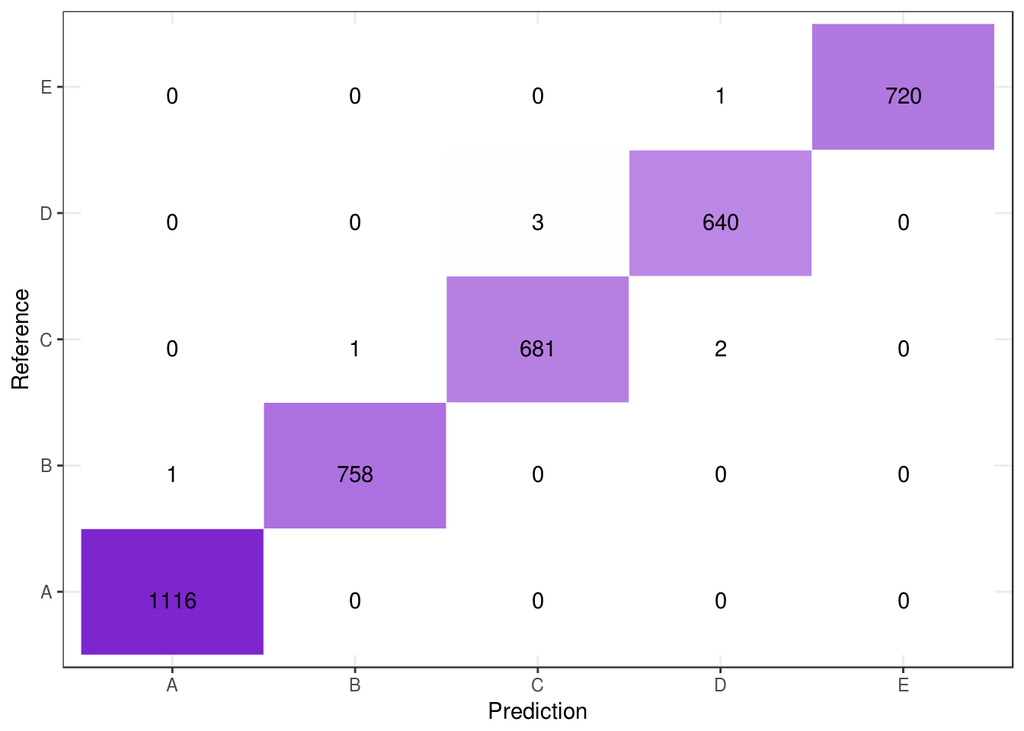

```r
df <- as.data.frame(confMxRf$table)
ggplot(data =  df, mapping = aes(x = Prediction, y = Reference)) +
  geom_tile(aes(fill = Freq), colour = "white") +
  geom_text(aes(label = sprintf("%1.0f", Freq)), vjust = 1) +
  scale_fill_gradient(low = "white", high = "purple3") +
  theme_bw() + theme(legend.position = "none")
```

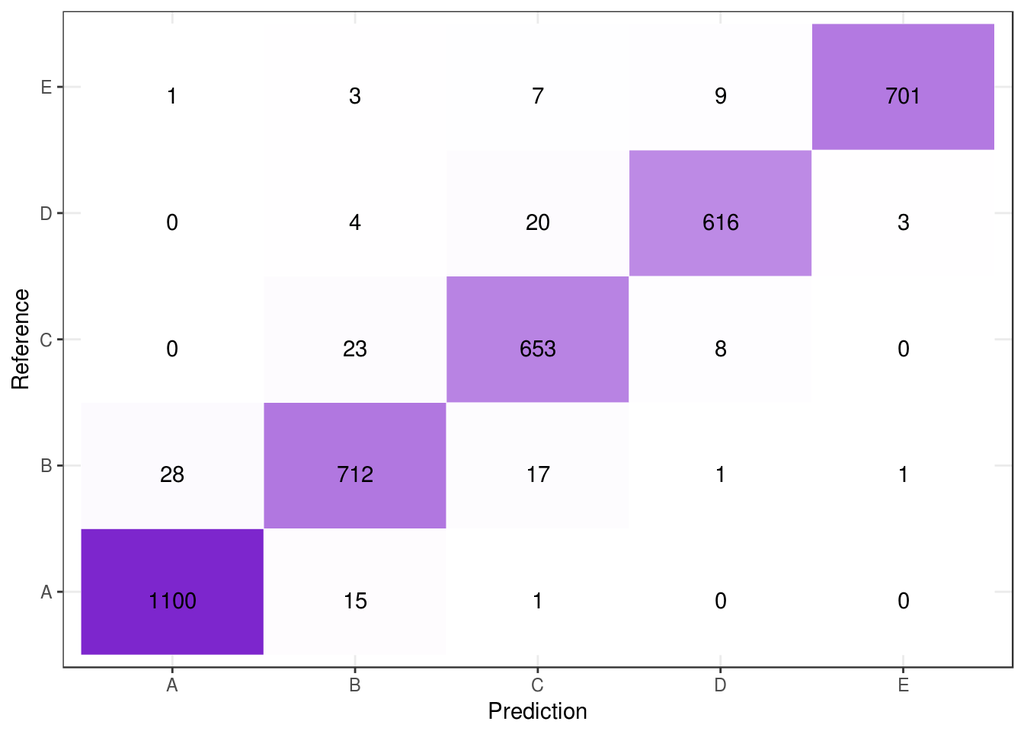

```r
dfGbm <- as.data.frame(confMxGbm$table)
ggplot(data =  dfGbm, mapping = aes(x = Prediction, y = Reference)) +
  geom_tile(aes(fill = Freq), colour = "white") +
  geom_text(aes(label = sprintf("%1.0f", Freq)), vjust = 1) +
  scale_fill_gradient(low = "white", high = "purple3") +
  theme_bw() + theme(legend.position = "none")
```

## References

1. http://groupware.les.inf.puc-rio.br/har
2. Ugulino, W.; Cardador, D.; Vega, K.; Velloso, E.; Milidiu, R.; Fuks, H. Wearable Computing: Accelerometers’ Data Classification of Body Postures and Movements. Proceedings of 21st Brazilian Symposium on Artificial Intelligence. Advances in Artificial Intelligence - SBIA 2012. In: Lecture Notes in Computer Science. , pp. 52-61. Curitiba, PR: Springer Berlin / Heidelberg, 2012. ISBN 978-3-642-34458-9. DOI: 10.1007/978-3-642-34459-6_6.
3. Qualitative Activity Recognition of Weight Lifting Exercises: http://groupware.les.inf.puc-rio.br/public/papers/2013.Velloso.QAR-WLE.pdf

## Appendix

**You don’t have to read this part.**

```r
  str(pml_training, list.len=200)
```

```
## 'data.frame':    19622 obs. of  160 variables:
##  $ X                       : int  1 2 3 4 5 6 7 8 9 10 ...
##  $ user_name               : chr  "carlitos" "carlitos" "carlitos" "carlitos" ...
##  $ raw_timestamp_part_1    : int  1323084231 1323084231 1323084231 1323084232 1323084232 1323084232 1323084232 1323084232 1323084232 1323084232 ...
##  $ raw_timestamp_part_2    : int  788290 808298 820366 120339 196328 304277 368296 440390 484323 484434 ...
##  $ cvtd_timestamp          : chr  "05/12/2011 11:23" "05/12/2011 11:23" "05/12/2011 11:23" "05/12/2011 11:23" ...
##  $ new_window              : chr  "no" "no" "no" "no" ...
##  $ num_window              : int  11 11 11 12 12 12 12 12 12 12 ...
##  $ roll_belt               : num  1.41 1.41 1.42 1.48 1.48 1.45 1.42 1.42 1.43 1.45 ...
##  $ pitch_belt              : num  8.07 8.07 8.07 8.05 8.07 8.06 8.09 8.13 8.16 8.17 ...
##  $ yaw_belt                : num  -94.4 -94.4 -94.4 -94.4 -94.4 -94.4 -94.4 -94.4 -94.4 -94.4 ...
##  $ total_accel_belt        : int  3 3 3 3 3 3 3 3 3 3 ...
##  $ kurtosis_roll_belt      : num  NA NA NA NA NA NA NA NA NA NA ...
##  $ kurtosis_picth_belt     : num  NA NA NA NA NA NA NA NA NA NA ...
##  $ kurtosis_yaw_belt       : num  NA NA NA NA NA NA NA NA NA NA ...
```

[output cut: 146 more lines]